# HiFi Full-length 16S Analysis Report

## Summary QC statistics

- Samples number: 12
- Final samples number post-DADA2: 12
- Missing samples (Not enough reads, do not pass QC, etc):
- Total number of CCS reads before filtering and primers trimming: 239076
- Was primers trimmed prior to DADA2? Yes
- Note that if downsampling was enabled, the reads will be filtered first, then restricted to a maximum of N reads.
- Total number of reads after quality filtering: 236793 (99.05%)
- Total number of reads after primers trimming (DADA2 input): 232379 (98.14%)
- Total number of ASVs found: 7127
- Average number of ASVs per sample: 832
- Total number of reads in 7127 ASVs: 102019 (43.9% of all input reads)

### Classification using VSEARCH with a single database

- ASVs classified at Species level: 2009 (28.19%)
- ASVs classified at Species level (Excluding metagenome/uncultured entries): 2009 (28.19%)
- Percentage reads belong to ASV classified at Species level (Excluding metagenome/uncultured entries): 31%
- ASVs classified at Genus level: 2083 (29.23%)
- ASVs classified at Genus level (Excluding metagenome/uncultured entries): 2083 (29.23%)
- Percentage reads belong to ASV classified at Genus level (Excluding metagenome/uncultured entries): 32%

### Classification using Naive Bayes classifier with SILVA, GTDB and RefSeq + RDP

- ASVs classified at Species level: 4270 (59.91%)
- ASVs classified at Species level (Excluding metagenome/uncultured entries): 4270 (59.91%)
- Percentage reads belong to ASV classified at Species level (Excluding metagenome/uncultured entries): 58%
- ASVs classified at Genus level: 4959 (69.58%)
- ASVs classified at Genus level (Excluding metagenome/uncultured entries): 4646 (65.19%)
- Percentage reads belong to ASV classified at Genus level (Excluding metagenome/uncultured entries): 66%

## Overall reads filtering and number of full-length reads

- Full-length reads are defined as reads with both F27 and R1492 primers
- Note that full length counts column will only show if cutadapt was used to trim primers (default).

|  | Sample | Reads before quality filter | Reads after quality filter | Full-length Reads | Full-length Reads Percent |
| --- | --- | --- | --- | --- | --- |
| 1 | Bacteria_AS1 | 19765 | 19616 | 19339 | 0.985878874388255 |
| 2 | Bacteria_AS2 | 20069 | 19815 | 19484 | 0.983295483219783 |
| 3 | Bacteria_AS3 | 19485 | 19257 | 18845 | 0.978605182531028 |
| 4 | Bacteria_AS4 | 19970 | 19769 | 19410 | 0.98184025494461 |
| 5 | Bacteria_AS5 | 19994 | 19831 | 19497 | 0.983157682416419 |
| 6 | Bacteria_AS6 | 19947 | 19810 | 19423 | 0.980464411913175 |
| 7 | Bacteria_FS1 | 19886 | 19612 | 19217 | 0.979859269834795 |
| 8 | Bacteria_FS2 | 19971 | 19795 | 19423 | 0.981207375599899 |
| 9 | Bacteria_SE1 | 19938 | 19786 | 19398 | 0.980390174871121 |
| 10 | Bacteria_SE2 | 19977 | 19810 | 19446 | 0.981625441696113 |

[output cut: 2 more lines]

## Input reads QC (Before filtering and primers removal)

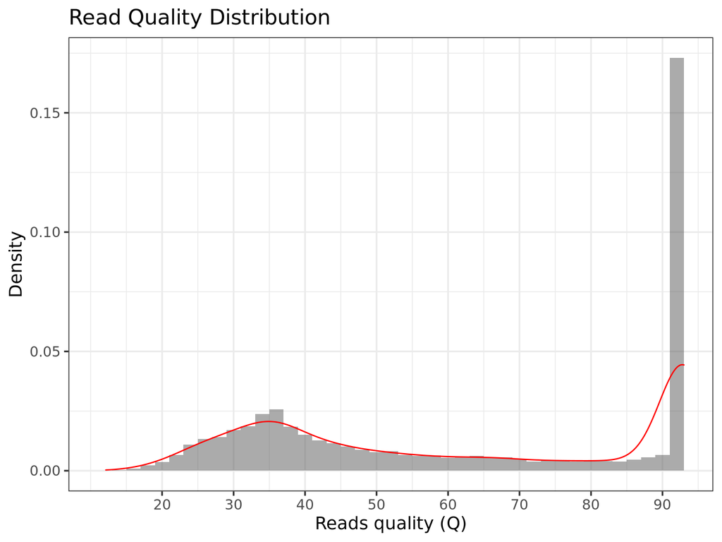

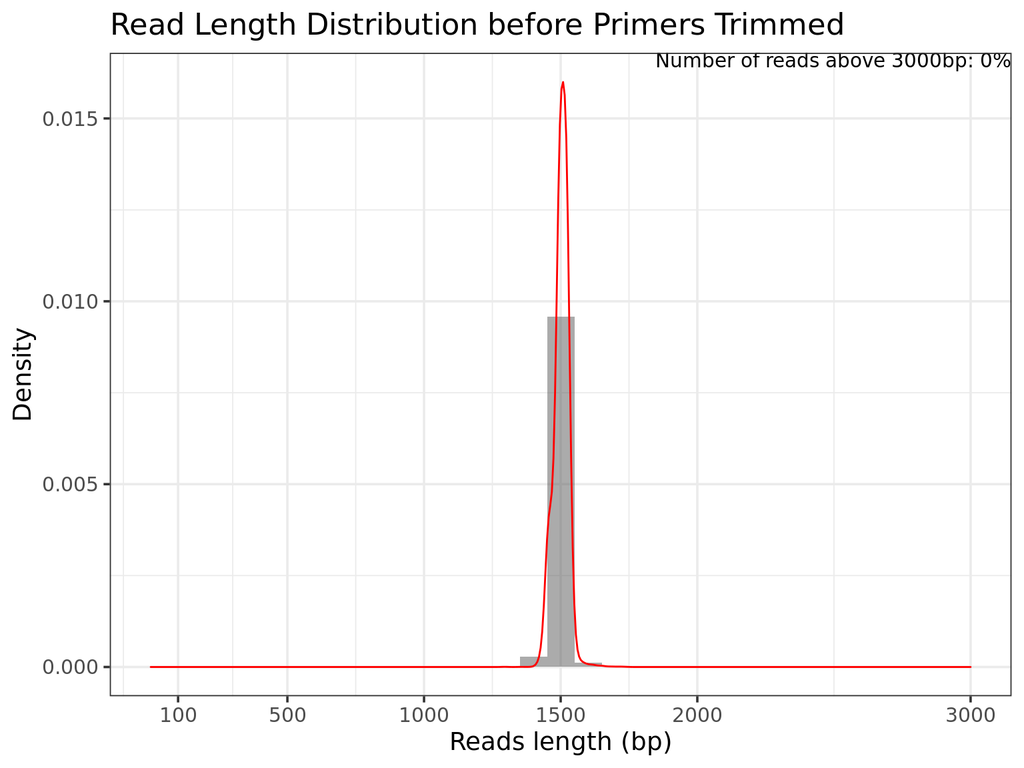

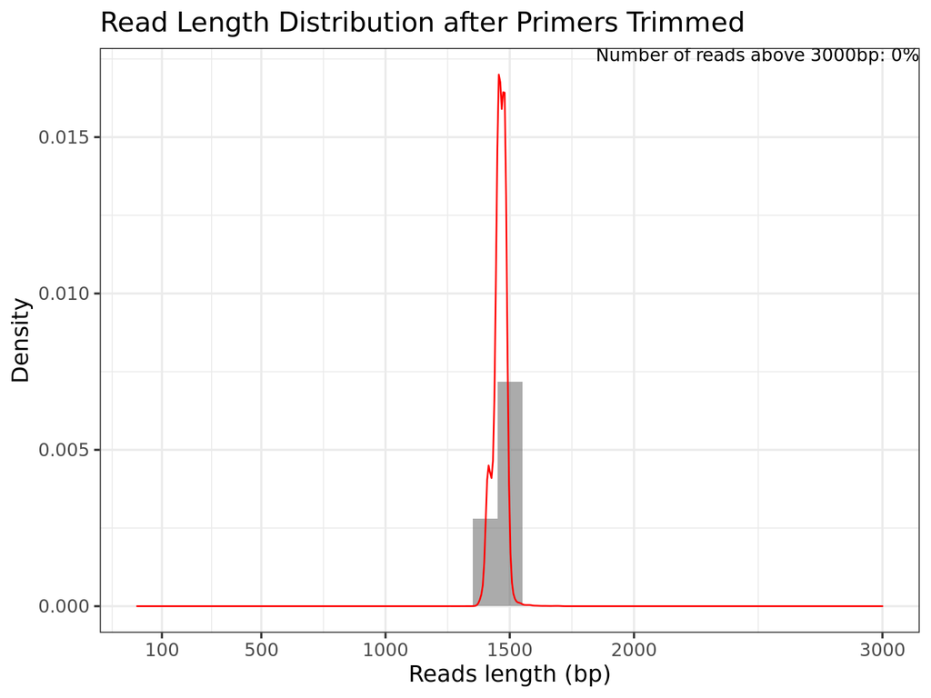

|  | Sample | Median Length (bp) | Median Read Quality | Length 1st Quartile (bp) | Length 3rd Quartile (bp) | Read Quality 1st Quartile (bp) | Read Quality 3rd Quartile (bp) |
| --- | --- | --- | --- | --- | --- | --- | --- |
| 1 | Bacteria_AS1 | 1504 | 67.63 | 1492 | 1519 | 38.62 | 93 |
| 2 | Bacteria_AS2 | 1504 | 49.84 | 1490 | 1519 | 33.92 | 92.99 |
| 3 | Bacteria_AS3 | 1505 | 48.75 | 1491 | 1519 | 33.59 | 92.88 |
| 4 | Bacteria_AS4 | 1507 | 58.82 | 1488 | 1522 | 35.76 | 93 |
| 5 | Bacteria_AS5 | 1506 | 63.88 | 1491 | 1521 | 37.6 | 93 |
| 6 | Bacteria_AS6 | 1501 | 69.46 | 1489 | 1518 | 38.95 | 93 |
| 7 | Bacteria_FS1 | 1509 | 44.97 | 1492 | 1524 | 32.94 | 91.73 |
| 8 | Bacteria_FS2 | 1505 | 61.17 | 1493 | 1523 | 36.73 | 93 |
| 9 | Bacteria_SE1 | 1505 | 63.81 | 1493 | 1521 | 37.33 | 93 |
| 10 | Bacteria_SE2 | 1500 | 70.66 | 1492 | 1520 | 38.83 | 93 |

[output cut: 2 more lines]

## DADA2 QC metrics

|  | sample-id | input | filtered | percentage of input passed filter | denoised | non-chimeric | percentage of input non-chimeric | n_ASV |
| --- | --- | --- | --- | --- | --- | --- | --- | --- |
| 1 | Bacteria_AS1 | 19339 | 17987 | 93.01 | 9535 | 9535 | 49.3 | 896 |
| 2 | Bacteria_AS2 | 19484 | 17281 | 88.69 | 6701 | 6692 | 34.35 | 610 |
| 3 | Bacteria_AS3 | 18845 | 16677 | 88.5 | 6736 | 6736 | 35.74 | 738 |
| 4 | Bacteria_AS4 | 19410 | 17647 | 90.92 | 9915 | 9915 | 51.08 | 955 |
| 5 | Bacteria_AS5 | 19497 | 18072 | 92.69 | 11705 | 11694 | 59.98 | 1060 |
| 6 | Bacteria_AS6 | 19423 | 18144 | 93.42 | 12197 | 12191 | 62.77 | 1017 |
| 7 | Bacteria_FS1 | 19217 | 16848 | 87.67 | 6794 | 6794 | 35.35 | 534 |
| 8 | Bacteria_FS2 | 19423 | 17852 | 91.91 | 11352 | 11352 | 58.45 | 868 |
| 9 | Bacteria_SE1 | 19398 | 17970 | 92.64 | 9803 | 9803 | 50.54 | 824 |
| 10 | Bacteria_SE2 | 19446 | 18185 | 93.52 | 12197 | 12188 | 62.68 | 981 |

[output cut: 2 more lines]

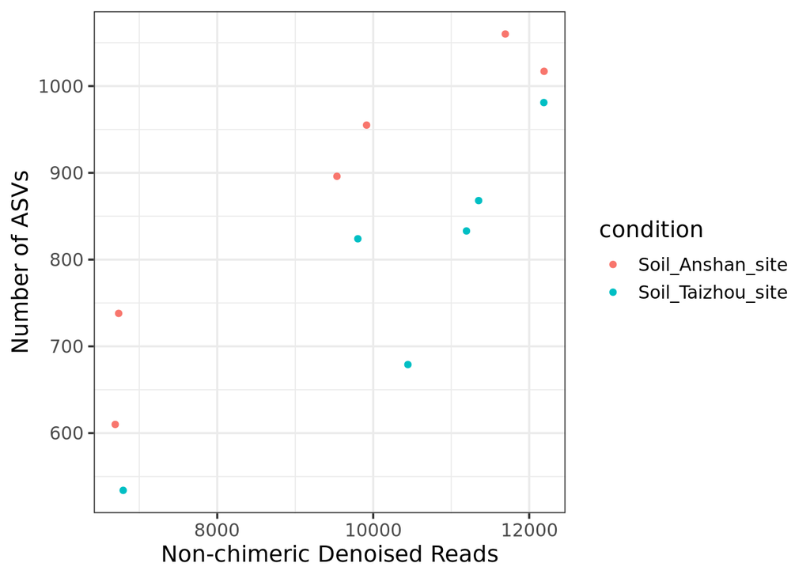

## Top Taxa and Plots

- For interactive view, use the Emperor QZV output from QIIME2 in `results/core-metrics-diversity` folder with QIIME2 View
- Note that if the distances between all samples are zero for a specific method, the plots will not be shown.
- MDS plots use ASVs as input.
- Samples might be missing due to choice of rarefecation depth. Rerun pipeline with `-resume --rarefaction_depth X` to choose a custom rarefaction depth X.

### Bray-Curtis MDS plot

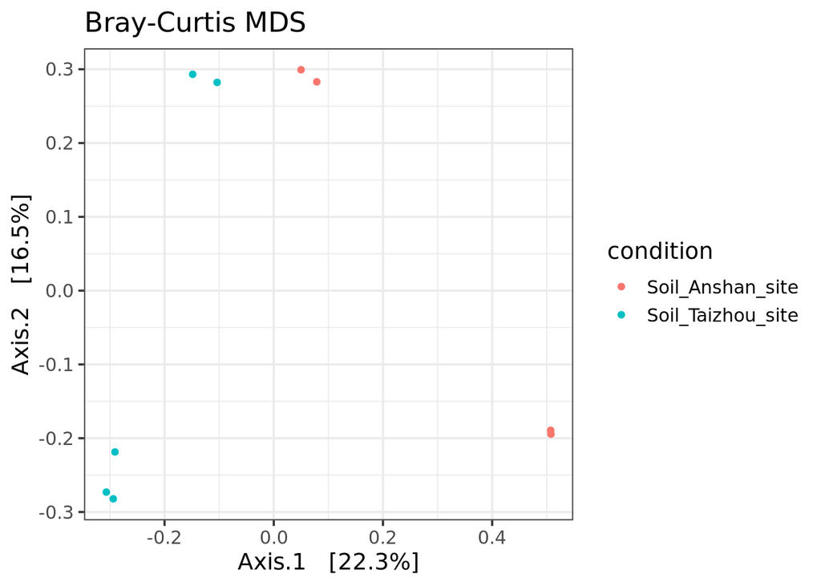

### Weighted and Unweighted Unifrac MDS plot

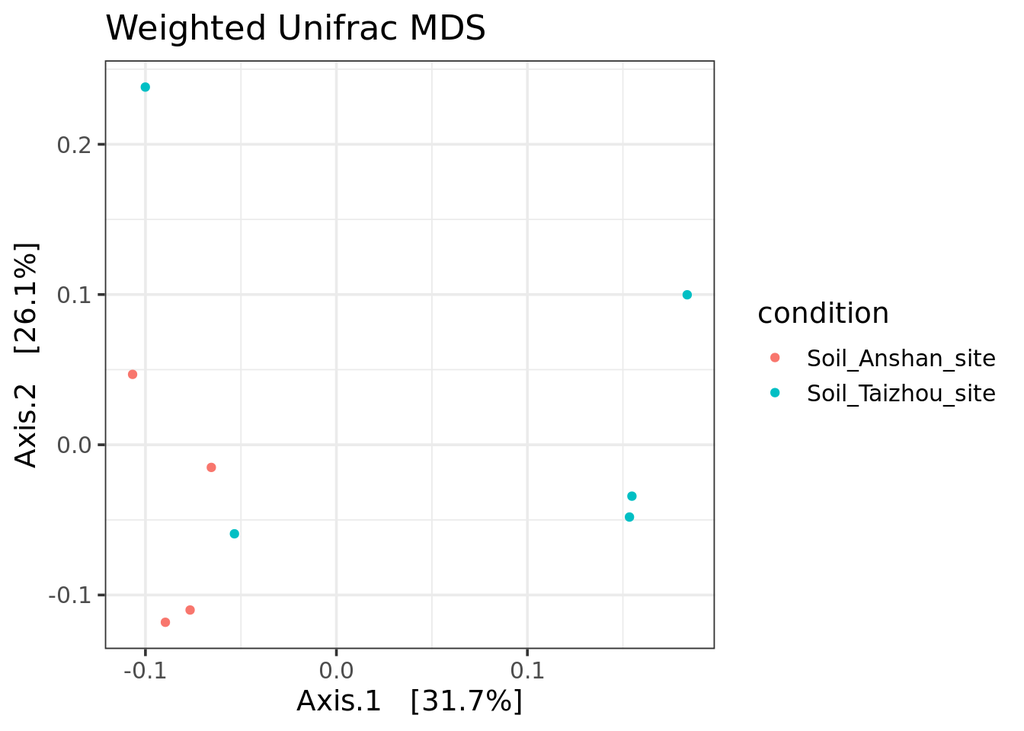

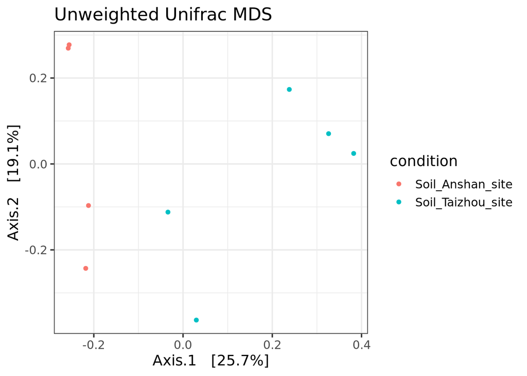

### Top 50 ASVs (VSEARCH classification)

|  | OTU | Kingdom | Phylum | Class | Order | Family | Genus | Species | Bacteria_AS1 | Bacteria_FS2 | Bacteria_FS1 | Bacteria_AS2 | Bacteria_SS2 | Bacteria_SS1 | Bacteria_SE1 | Bacteria_AS5 | Bacteria_AS6 | Bacteria_AS4 | Bacteria_AS3 | Bacteria_SE2 |
| --- | --- | --- | --- | --- | --- | --- | --- | --- | --- | --- | --- | --- | --- | --- | --- | --- | --- | --- | --- | --- |
| 1 | e9b142e34e795428921766c8c0241bf4 | Unassigned |  |  |  |  |  |  | 0 | 56 | 107 | 0 | 1 | 0 | 27 | 0 | 0 | 0 | 0 | 69 |
| 2 | 4a9fe63de8317196c7ab1aad2adce114 | Bacteria | Proteobacteria | Gammaproteobacteria | Burkholderiales | Burkholderiaceae | Ramlibacter | Ramlibacter monticola | 6 | 8 | 0 | 0 | 143 | 44 | 16 | 0 | 0 | 0 | 0 | 7 |
| 3 | f0ece87e6f4450492fc8b9707d47878f | Unassigned |  |  |  |  |  |  | 0 | 69 | 76 | 0 | 0 | 0 | 8 | 0 | 0 | 0 | 0 | 64 |
| 4 | c7a2b98c07bed93f759c21becc233010 | Unassigned |  |  |  |  |  |  | 0 | 0 | 0 | 0 | 0 | 0 | 191 | 0 | 0 | 0 | 0 | 6 |
| 5 | a4b3b69506dd63a790f32e337904d3d6 | Bacteria | Proteobacteria | Gammaproteobacteria | Burkholderiales | SG8-39 | SCGC-AG-212-J23 | SCGC-AG-212-J23 sp005881595 | 27 | 0 | 0 | 67 | 0 | 0 | 0 | 20 | 0 | 36 | 31 | 0 |
| 6 | c0cc185eb82351a8406d785389a07ce5 | Unassigned |  |  |  |  |  |  | 0 | 0 | 0 | 0 | 0 | 172 | 0 | 0 | 0 | 0 | 0 | 0 |
| 7 | a1c308e01db57447c0729f689f53e20d | Unassigned |  |  |  |  |  |  | 0 | 0 | 0 | 0 | 0 | 0 | 0 | 62 | 0 | 66 | 39 | 0 |
| 8 | 1101bfee506ce89845b9db9aea426b23 | Bacteria | Proteobacteria | Gammaproteobacteria | Burkholderiales | Rhodocyclaceae | Aromatoleum | Aromatoleum tolulyticum | 0 | 0 | 0 | 0 | 134 | 3 | 27 | 0 | 0 | 0 | 0 | 2 |
| 9 | c73f6082c5fb974b42983e5e8b22b573 | Unassigned |  |  |  |  |  |  | 0 | 5 | 105 | 0 | 0 | 0 | 39 | 0 | 0 | 0 | 0 | 11 |
| 10 | c09e07532d495fe647fb58e53d70a9b9 | Unassigned |  |  |  |  |  |  | 0 | 0 | 0 | 0 | 0 | 159 | 0 | 0 | 0 | 0 | 0 | 0 |

[output cut: 40 more lines]

### Top 10 Classified Genus (Collapsed to species) with VSEARCH

- Relative abundance is calculated by dividing the number of reads for each ASV to the total number of reads in each sample.
- Heatmap contains only species with >1% abundance in at least 2 samples for the top 10 genus.

|  | Genus | Mean supporting reads across samples | Mean relative abundance across samples |
| --- | --- | --- | --- |
| 1 | Ramlibacter | 142.25 | 0.02 |
| 2 | Sphingomicrobium | 213.83 | 0.02 |
| 3 | 12-FULL-67-14b | 61 | 0.01 |
| 4 | Anaeromyxobacter | 44.42 | 0.01 |
| 5 | Arenimonas | 45.25 | 0.01 |
| 6 | Flavisolibacter | 57.75 | 0.01 |
| 7 | Lysobacter | 132.5 | 0.01 |
| 8 | Nitrospira C | 55.92 | 0.01 |
| 9 | SCGC-AG-212-J23 | 82.08 | 0.01 |
| 10 | SCUD01 | 87.33 | 0.01 |

[output cut: 2 more lines]

|  | Genus | Species | Bacteria_AS1 | Bacteria_FS2 | Bacteria_FS1 | Bacteria_AS2 | Bacteria_SS2 | Bacteria_SS1 | Bacteria_SE1 | Bacteria_AS5 | Bacteria_AS6 | Bacteria_AS4 | Bacteria_AS3 | Bacteria_SE2 |
| --- | --- | --- | --- | --- | --- | --- | --- | --- | --- | --- | --- | --- | --- | --- |
| 1 | Ramlibacter |  | 0 | 0 | 0 | 0 | 37 | 0 | 0 | 0 | 0 | 0 | 0 | 2 |
| 2 | Ramlibacter | Ramlibacter alkalitolerans | 0 | 0 | 0 | 0 | 56 | 0 | 0 | 0 | 0 | 0 | 0 | 0 |
| 3 | Ramlibacter | Ramlibacter ginsenosidimutans | 20 | 0 | 0 | 0 | 0 | 0 | 0 | 7 | 31 | 0 | 2 | 0 |
| 4 | Ramlibacter | Ramlibacter lithotrophicus | 0 | 0 | 0 | 0 | 41 | 0 | 0 | 0 | 0 | 0 | 0 | 61 |
| 5 | Ramlibacter | Ramlibacter monticola | 22 | 37 | 8 | 0 | 548 | 75 | 52 | 0 | 5 | 0 | 9 | 11 |
| 6 | Ramlibacter | Ramlibacter soli | 0 | 0 | 0 | 0 | 28 | 0 | 21 | 13 | 12 | 0 | 6 | 0 |
| 7 | Ramlibacter | Ramlibacter sp001424545 | 0 | 0 | 0 | 0 | 13 | 0 | 0 | 0 | 0 | 0 | 0 | 0 |
| 8 | Ramlibacter | Ramlibacter sp007833165 | 12 | 6 | 0 | 6 | 31 | 2 | 1 | 0 | 52 | 9 | 9 | 3 |
| 9 | Ramlibacter | Ramlibacter sp013087525 | 5 | 0 | 0 | 0 | 29 | 19 | 24 | 0 | 10 | 0 | 0 | 7 |
| 10 | Ramlibacter | Ramlibacter sp013778345 | 0 | 0 | 0 | 0 | 25 | 0 | 0 | 0 | 0 | 0 | 0 | 0 |

[output cut: 68 more lines]

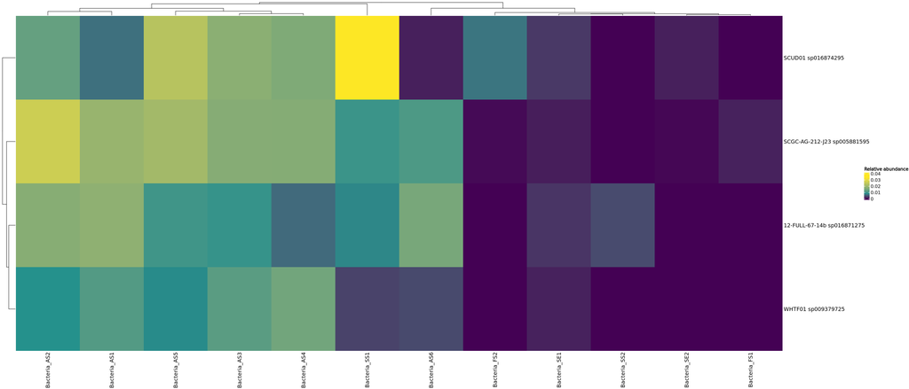

### Top 50 ASVs (Naive Bayes Classifier)

|  | OTU | Kingdom | Phylum | Class | Order | Family | Genus | Species | Bacteria_AS1 | Bacteria_FS2 | Bacteria_FS1 | Bacteria_AS2 | Bacteria_SS2 | Bacteria_SS1 | Bacteria_SE1 | Bacteria_AS5 | Bacteria_AS6 | Bacteria_AS4 | Bacteria_AS3 | Bacteria_SE2 |
| --- | --- | --- | --- | --- | --- | --- | --- | --- | --- | --- | --- | --- | --- | --- | --- | --- | --- | --- | --- | --- |
| 1 | e9b142e34e795428921766c8c0241bf4 | Bacteria | Verrucomicrobiota | Verrucomicrobiae | Chthoniobacterales | UBA10450 | Unclassified | Unclassified | 0 | 56 | 107 | 0 | 1 | 0 | 27 | 0 | 0 | 0 | 0 | 69 |
| 2 | 4a9fe63de8317196c7ab1aad2adce114 | Bacteria | Proteobacteria | Betaproteobacteria | Burkholderiales | Comamonadaceae | Ramlibacter | Ramlibacter monticola | 6 | 8 | 0 | 0 | 143 | 44 | 16 | 0 | 0 | 0 | 0 | 7 |
| 3 | f0ece87e6f4450492fc8b9707d47878f | Bacteria | Nitrospirota | Thermodesulfovibrionia | Thermodesulfovibrionales | UBA6898 | UBA6898 | UBA6898 sp016217675 | 0 | 69 | 76 | 0 | 0 | 0 | 8 | 0 | 0 | 0 | 0 | 64 |
| 4 | c7a2b98c07bed93f759c21becc233010 | Bacteria | Myxococcota | Myxococcia | Myxococcales | Anaeromyxobacteraceae | Anaeromyxobacter | Unclassified | 0 | 0 | 0 | 0 | 0 | 0 | 191 | 0 | 0 | 0 | 0 | 6 |
| 5 | a4b3b69506dd63a790f32e337904d3d6 | Bacteria | Proteobacteria | Gammaproteobacteria | Burkholderiales | SG8-39 | SCGC-AG-212-J23 | SCGC-AG-212-J23 sp005881595 | 27 | 0 | 0 | 67 | 0 | 0 | 0 | 20 | 0 | 36 | 31 | 0 |
| 6 | c0cc185eb82351a8406d785389a07ce5 | Bacteria | Desulfobacterota D | UBA1144 | RKRQ01 | RKRQ01 | RKRQ01 | Unclassified | 0 | 0 | 0 | 0 | 0 | 172 | 0 | 0 | 0 | 0 | 0 | 0 |
| 7 | a1c308e01db57447c0729f689f53e20d | Bacteria | Unclassified | Unclassified | Unclassified | Unclassified | Unclassified | Unclassified | 0 | 0 | 0 | 0 | 0 | 0 | 0 | 62 | 0 | 66 | 39 | 0 |
| 8 | 1101bfee506ce89845b9db9aea426b23 | Bacteria | Proteobacteria | Gammaproteobacteria | Burkholderiales | Rhodocyclaceae | Azoarcus | Azoarcus tolulyticus | 0 | 0 | 0 | 0 | 134 | 3 | 27 | 0 | 0 | 0 | 0 | 2 |
| 9 | c73f6082c5fb974b42983e5e8b22b573 | Bacteria | Proteobacteria | Alphaproteobacteria | Rhizobiales | Xanthobacteraceae | Pseudolabrys | Pseudolabrys taiwanensis | 0 | 5 | 105 | 0 | 0 | 0 | 39 | 0 | 0 | 0 | 0 | 11 |
| 10 | c09e07532d495fe647fb58e53d70a9b9 | Bacteria | Myxococcota A | UBA9160 | SZUA-336 | SZUA-336 | Unclassified | Unclassified | 0 | 0 | 0 | 0 | 0 | 159 | 0 | 0 | 0 | 0 | 0 | 0 |

[output cut: 40 more lines]

### Top 10 Classified Genus (Collapsed to species) with Naive Bayes Classifier

- Relative abundance is calculated by dividing the number of reads for each ASV to the total number of reads in each sample.
- Heatmap contains only species with >1% abundance in at least 2 samples for the top 10 genus.

|  | Genus | Mean supporting reads across samples | Mean relative abundance across samples |
| --- | --- | --- | --- |
| 1 |  | 286.92 | 0.03 |
| 2 | JACDCA01 | 222.58 | 0.03 |
| 3 | AR9 | 156 | 0.02 |
| 4 | Lysobacter | 135.33 | 0.02 |
| 5 | QHXM01 | 151 | 0.02 |
| 6 | Ramlibacter | 141.33 | 0.02 |
| 7 | SCGC-AG-212-J23 | 132.58 | 0.02 |
| 8 | Sphingomicrobium | 196.08 | 0.02 |
| 9 | VBCG01 | 133 | 0.02 |
| 10 | 12-FULL-67-14b | 72.83 | 0.01 |

[output cut: 19 more lines]

|  | Genus | Species | Bacteria_AS1 | Bacteria_FS2 | Bacteria_FS1 | Bacteria_AS2 | Bacteria_SS2 | Bacteria_SS1 | Bacteria_SE1 | Bacteria_AS5 | Bacteria_AS6 | Bacteria_AS4 | Bacteria_AS3 | Bacteria_SE2 |
| --- | --- | --- | --- | --- | --- | --- | --- | --- | --- | --- | --- | --- | --- | --- |
| 1 |  | Acidobacteria | 55 | 43 | 46 | 69 | 10 | 9 | 17 | 62 | 54 | 52 | 20 | 16 |
| 2 |  | Acidobacteriaceae | 0 | 0 | 0 | 0 | 0 | 0 | 0 | 0 | 0 | 5 | 0 | 0 |
| 3 |  | bacterium | 12 | 118 | 37 | 35 | 40 | 135 | 0 | 21 | 12 | 38 | 5 | 69 |
| 4 |  | catecholicum | 0 | 0 | 0 | 0 | 0 | 0 | 0 | 0 | 0 | 0 | 0 | 5 |
| 5 |  | delta | 0 | 0 | 0 | 0 | 0 | 0 | 0 | 3 | 0 | 2 | 0 | 0 |
| 6 |  | Ellin327 | 0 | 0 | 0 | 0 | 5 | 0 | 10 | 0 | 0 | 0 | 0 | 0 |
| 7 |  | Ellin5102 | 84 | 110 | 110 | 145 | 89 | 25 | 110 | 24 | 127 | 28 | 17 | 130 |
| 8 |  | eubacterium | 15 | 0 | 3 | 0 | 38 | 0 | 6 | 3 | 16 | 43 | 0 | 5 |
| 9 |  | hydrocarbon | 0 | 6 | 0 | 0 | 0 | 0 | 0 | 0 | 0 | 0 | 0 | 0 |
| 10 |  | Latescibacteria | 0 | 7 | 7 | 0 | 0 | 33 | 20 | 5 | 0 | 0 | 0 | 11 |

[output cut: 94 more lines]

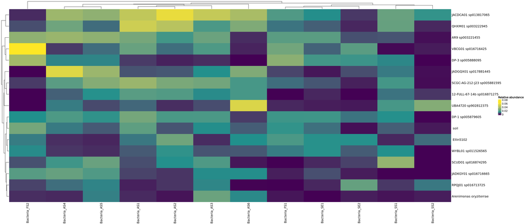